# Primeiros passos no R

Aula 2 | Organização, manipulação e visualização de dados

Na primeira aula, aprendemos a criar objetos, trabalhar com vetores e utilizar operadores lógicos e relacionais.

Agora, vamos aprender a reunir essas informações em tabelas, consultar observações e explorar conjuntos de dados.

## 1. Trabalhando com data frames

Até agora, armazenamos diferentes informações em vetores separados. Mas imagine que queremos reunir os nomes, as idades e outras características de um grupo de estudantes.

Para isso, podemos utilizar um **data frame**, uma estrutura de dados organizada em linhas e colunas, semelhante a uma planilha.

Em um data frame:

- Cada **linha** representa uma observação.
- Cada **coluna** representa uma variável.
- As colunas podem armazenar diferentes tipos de dados, como números, caracteres e valores lógicos.

### Criando os vetores

Para começar, precisamos coletar três informações de cada participante:

1. **Nome:** como você gostaria de ser identificado?
2. **Idade:** quantos anos você tem?
3. **Irmãos:** você possui irmãos? (Sim ou não)

Vamos registrar essas informações em três vetores.

**Primeiro, os nomes:**

```r
nome <- c("x", "x", "x", "x", "x",
          "x", "x", "x", "x", "x")
```

**Agora, as idades:**

```r
idade <- c(0, 0, 0, 0, 0, 0, 0, 0, 0, 0)
```

**Por último, vamos registrar quem possui irmãos:**

```r
irmaos <- c(TRUE, FALSE, TRUE, TRUE, FALSE,
            TRUE, FALSE, TRUE, TRUE, FALSE)
```

Lembre-se:

- `TRUE`: possui irmãos.
- `FALSE`: não possui irmãos.

### Conferindo nossos dados

Antes de criar a tabela, precisamos verificar se os três vetores possuem o mesmo número de elementos.

```r
length(nome)
```

```
## [1] 10
```

```r
length(idade)
```

```
## [1] 10
```

```r
length(irmaos)
```

```
## [1] 10
```

**Vamos pensar:** o que aconteceria se tivéssemos dez nomes, mas apenas nove idades?

### Criando um data frame

Agora, vamos reunir esses três vetores em uma única tabela utilizando a função `data.frame()`.

```r
dados_alunos <- data.frame(nome, idade, irmaos)

dados_alunos
```

```
##    nome idade irmaos
## 1     x     0   TRUE
## 2     x     0  FALSE
## 3     x     0   TRUE
## 4     x     0   TRUE
## 5     x     0  FALSE
## 6     x     0   TRUE
## 7     x     0  FALSE
## 8     x     0   TRUE
## 9     x     0   TRUE
## 10    x     0  FALSE
```

Observe que cada estudante ocupa uma linha, enquanto as informações são organizadas em três colunas.

**Atenção:** os vetores utilizados precisam ter comprimentos compatíveis. Neste exemplo, todos possuem dez elementos, permitindo associar corretamente as informações de cada estudante.

Também podemos construir o data frame diretamente, sem criar os vetores separadamente.

```r
dados_alunos <- data.frame(
  nome = c("x", "x", "x", "x", "x", "x", "x", "x", "x", "x"),
  idade = c(0, 0, 0, 0, 0, 0, 0, 0, 0, 0),
  irmaos = c(TRUE, TRUE, TRUE, TRUE, TRUE,
             TRUE, FALSE, TRUE, TRUE, TRUE)
)

dados_alunos
```

```
##    nome idade irmaos
## 1     x     0   TRUE
## 2     x     0   TRUE
## 3     x     0   TRUE
## 4     x     0   TRUE
## 5     x     0   TRUE
## 6     x     0   TRUE
## 7     x     0  FALSE
## 8     x     0   TRUE
## 9     x     0   TRUE
## 10    x     0   TRUE
```

### Conhecendo nosso data frame

Depois de criar um data frame, podemos utilizar diferentes funções para conhecer sua estrutura.

```r
dados_alunos
```

```
##    nome idade irmaos
## 1     x     0   TRUE
## 2     x     0   TRUE
## 3     x     0   TRUE
## 4     x     0   TRUE
## 5     x     0   TRUE
## 6     x     0   TRUE
## 7     x     0  FALSE
## 8     x     0   TRUE
## 9     x     0   TRUE
## 10    x     0   TRUE
```

A função `View()` abre os dados em uma janela do RStudio, facilitando sua visualização.

```r
View(dados_alunos)
```

Também podemos examinar sua estrutura:

```r
str(dados_alunos)
```

```
## 'data.frame':    10 obs. of  3 variables:
##  $ nome  : chr  "x" "x" "x" "x" ...
##  $ idade : num  0 0 0 0 0 0 0 0 0 0
##  $ irmaos: logi  TRUE TRUE TRUE TRUE TRUE TRUE ...
```

Essa função mostra o número de observações, as variáveis e os tipos de dados armazenados em cada coluna.

Para obter um resumo das variáveis:

```r
summary(dados_alunos)
```

```
##      nome               idade     irmaos
##  Length:10          Min.   :0   Mode :logical
##  Class :character   1st Qu.:0   FALSE:1
##  Mode  :character   Median :0   TRUE :9
##                     Mean   :0
##                     3rd Qu.:0
##                     Max.   :0
```

Outras funções permitem consultar as dimensões do conjunto de dados:

```r
dim(dados_alunos)   # Número de linhas e colunas
```

```
## [1] 10  3
```

```r
nrow(dados_alunos)  # Número de linhas
```

```
## [1] 10
```

```r
ncol(dados_alunos)  # Número de colunas
```

```
## [1] 3
```

**Vamos praticar!**

1. Quantas observações existem no data frame?
2. Quantas variáveis foram registradas?
3. Qual é o tipo de dado armazenado em cada coluna?
4. Qual é a menor e a maior idade dos estudantes?

### Consultando linhas e colunas

Assim como utilizamos colchetes para consultar elementos de um vetor, podemos utilizá-los para acessar informações de um data frame.

A diferença é que, agora, precisamos considerar duas dimensões:

**`dados[linha, coluna]`**

O primeiro argumento indica a linha e o segundo indica a coluna.

Por exemplo, para consultar o nome do quinto estudante:

```r
dados_alunos[5, 1]
```

```
## [1] "x"
```

Para consultar todas as informações do décimo estudante:

```r
dados_alunos[10, ]
```

```
##    nome idade irmaos
## 10    x     0   TRUE
```

Observe que deixamos o espaço após a vírgula vazio. Isso significa que queremos consultar todas as colunas daquela linha.

E se quisermos consultar as idades de todos os estudantes?

```r
dados_alunos[, 2]
```

```
##  [1] 0 0 0 0 0 0 0 0 0 0
```

Nesse caso, deixamos o espaço antes da vírgula vazio, indicando que queremos todas as linhas da segunda coluna.

Também podemos selecionar várias linhas e colunas ao mesmo tempo:

```r
dados_alunos[1:3, 1:2]
```

```
##   nome idade
## 1    x     0
## 2    x     0
## 3    x     0
```

O comando retorna as três primeiras linhas e as duas primeiras colunas.

### Acessando variáveis pelo nome

Outra maneira de acessar uma coluna é utilizando o operador `$`.

```r
dados_alunos$nome
```

```
##  [1] "x" "x" "x" "x" "x" "x" "x" "x" "x" "x"
```

```r
dados_alunos$idade
```

```
##  [1] 0 0 0 0 0 0 0 0 0 0
```

```r
dados_alunos$irmaos
```

```
##  [1]  TRUE  TRUE  TRUE  TRUE  TRUE  TRUE FALSE  TRUE  TRUE  TRUE
```

Essa forma é bastante utilizada porque permite acessar diretamente uma variável pelo seu nome, sem precisar lembrar sua posição na tabela.

### Selecionando observações com condições

Na primeira aula, aprendemos a utilizar operadores relacionais para identificar valores que atendem a determinadas condições.

Agora, podemos aplicar esses conhecimentos aos data frames.

**Quais estudantes possuem 20 anos ou mais?**

Primeiro, vamos identificar quais observações atendem à condição:

```r
dados_alunos$idade >= 20
```

```
##  [1] FALSE FALSE FALSE FALSE FALSE FALSE FALSE FALSE FALSE FALSE
```

Depois, podemos utilizar essa condição para consultar apenas os nomes desses estudantes:

```r
dados_alunos$nome[dados_alunos$idade >= 20]
```

```
## character(0)
```

Também podemos selecionar todas as informações dos estudantes com 20 anos ou mais:

```r
dados_alunos[dados_alunos$idade >= 20, ]
```

```
## [1] nome   idade  irmaos
## <0 linhas> (ou row.names de comprimento 0)
```

**Qual é a idade da estudante fulana?**

```r
dados_alunos$idade[dados_alunos$nome == "fulana"]
```

```
## numeric(0)
```

**Quais estudantes não possuem irmãos?**

```r
dados_alunos$nome[dados_alunos$irmaos == FALSE]
```

```
## [1] "x"
```

Observe que estamos combinando conceitos já conhecidos: vetores, índices, operadores relacionais e valores lógicos.

### Consultando os nomes das variáveis

Podemos consultar os nomes das colunas e das linhas utilizando:

```r
colnames(dados_alunos)
```

```
## [1] "nome"   "idade"  "irmaos"
```

```r
rownames(dados_alunos)
```

```
##  [1] "1"  "2"  "3"  "4"  "5"  "6"  "7"  "8"  "9"  "10"
```

Também podemos alterar os nomes das colunas.

```r
colnames(dados_alunos) <- c("Nome", "Idade", "Irmaos")

dados_alunos
```

```
##    Nome Idade Irmaos
## 1     x     0   TRUE
## 2     x     0   TRUE
## 3     x     0   TRUE
## 4     x     0   TRUE
## 5     x     0   TRUE
## 6     x     0   TRUE
## 7     x     0  FALSE
## 8     x     0   TRUE
## 9     x     0   TRUE
## 10    x     0   TRUE
```

Observe que o R diferencia letras maiúsculas e minúsculas. Portanto, após a alteração, precisamos utilizar os novos nomes para acessar as variáveis.

```r
dados_alunos$Idade
```

```
##  [1] 0 0 0 0 0 0 0 0 0 0
```

O R possui dois objetos que permitem acessar as letras do alfabeto:

- `letters`: letras minúsculas (`a` até `z`).
- `LETTERS`: letras maiúsculas (`A` até `Z`).

Podemos utilizar os colchetes para selecionar apenas algumas letras.

```r
y <- letters[1:10]
y
```

```
##  [1] "a" "b" "c" "d" "e" "f" "g" "h" "i" "j"
```

```r
z <- LETTERS[1:10]
z
```

```
##  [1] "A" "B" "C" "D" "E" "F" "G" "H" "I" "J"
```

Observe que os dois comandos retornam as dez primeiras letras do alfabeto, diferenciando apenas as letras maiúsculas e minúsculas.

### Aplicando ao nosso data frame

Imagine que queremos identificar cada estudante com uma letra, em vez de utilizar números nas linhas.

Podemos modificar os nomes das linhas utilizando `rownames()`.

```r
rownames(dados_alunos) <- LETTERS[1:10]

dados_alunos
```

```
##   Nome Idade Irmaos
## A    x     0   TRUE
## B    x     0   TRUE
## C    x     0   TRUE
## D    x     0   TRUE
## E    x     0   TRUE
## F    x     0   TRUE
## G    x     0  FALSE
## H    x     0   TRUE
## I    x     0   TRUE
## J    x     0   TRUE
```

Agora, cada linha está identificada por uma letra de A até J.

Também podemos consultar uma observação utilizando essa identificação.

```r
dados_alunos["C", ]
```

```
##   Nome Idade Irmaos
## C    x     0   TRUE
```

### Vamos praticar!

Utilizando o data frame `dados_alunos`, responda:

1. Consulte todas as informações do terceiro estudante.
2. Consulte apenas os nomes dos cinco primeiros estudantes.
3. Quais estudantes possuem menos de 20 anos?
4. Quantos estudantes possuem 21 anos?
5. Quais estudantes possuem irmãos e têm mais de 20 anos?
6. Consulte as linhas 2, 4 e 6, mostrando apenas as colunas de nome e idade.

## 2. Trabalhando com listas

Na primeira aula, aprendemos que um vetor armazena elementos de um mesmo tipo. Mas e se quisermos guardar números, textos, vetores e até tabelas dentro de um único objeto?

Para isso, podemos utilizar as **listas**.

Uma lista é uma estrutura que permite armazenar diferentes tipos de objetos, inclusive objetos de tamanhos distintos.

### Criando nossa primeira lista

Vamos começar com dois vetores numéricos:

```r
x <- c(3, 2, 3)
y <- c(7, 7)
```

Observe que os vetores possuem comprimentos diferentes.

Agora, vamos reuni-los utilizando a função `list()`.

```r
z <- list(x = x, y = y)

z
```

```
## $x
## [1] 3 2 3
##
## $y
## [1] 7 7
```

Nesse exemplo, criamos uma lista com dois elementos, chamados `x` e `y`. Cada elemento contém um vetor.

### Criando uma lista com os dados da turma

Na seção anterior, criamos três vetores contendo os nomes, as idades e a informação sobre irmãos dos participantes.

Vamos reunir essas informações em uma lista.

```r
lista_alunos <- list(nome, idade, irmaos)

lista_alunos
```

```
## [[1]]
##  [1] "x" "x" "x" "x" "x" "x" "x" "x" "x" "x"
##
## [[2]]
##  [1] 0 0 0 0 0 0 0 0 0 0
##
## [[3]]
##  [1]  TRUE FALSE  TRUE  TRUE FALSE  TRUE FALSE  TRUE  TRUE FALSE
```

Também podemos atribuir nomes aos elementos da lista, facilitando sua identificação.

```r
lista_alunos_nomeada <- list(
  Nomes = nome,
  Idades = idade,
  Irmaos = irmaos
)

lista_alunos_nomeada
```

```
## $Nomes
##  [1] "x" "x" "x" "x" "x" "x" "x" "x" "x" "x"
##
## $Idades
##  [1] 0 0 0 0 0 0 0 0 0 0
##
## $Irmaos
##  [1]  TRUE FALSE  TRUE  TRUE FALSE  TRUE FALSE  TRUE  TRUE FALSE
```

**Qual é a diferença entre a lista e o data frame que criamos anteriormente?**

No data frame, os dados estão organizados em linhas e colunas, e cada linha corresponde a um estudante.

Na lista, os objetos são armazenados como elementos independentes. Nesse caso, temos três elementos: um vetor com nomes, outro com idades e outro com informações sobre irmãos.

### Listas com diferentes objetos

Uma lista também pode armazenar estruturas mais complexas.

Vamos criar uma lista que reúna uma sequência numérica, nosso data frame, outro conjunto de dados, valores lógicos e um texto.

```r
random_list <- list(
  78:15,
  dados_alunos,
  datasets::iris,
  c(TRUE, FALSE, TRUE, TRUE),
  "aula"
)

random_list
```

```
## [[1]]
##  [1] 78 77 76 75 74 73 72 71 70 69 68 67 66 65 64 63 62 61 60 59 58 57 56 55 54
## [26] 53 52 51 50 49 48 47 46 45 44 43 42 41 40 39 38 37 36 35 34 33 32 31 30 29
## [51] 28 27 26 25 24 23 22 21 20 19 18 17 16 15
##
## [[2]]
##   Nome Idade Irmaos
## A    x     0   TRUE
## B    x     0   TRUE
## C    x     0   TRUE
## D    x     0   TRUE
## E    x     0   TRUE
## F    x     0   TRUE
## G    x     0  FALSE
## H    x     0   TRUE
```

[output cut: 161 more lines]

Observe que cada elemento da lista possui uma estrutura diferente.

Podemos utilizar a função `str()` para examinar sua organização.

```r
str(random_list)
```

```
## List of 5
##  $ : int [1:64] 78 77 76 75 74 73 72 71 70 69 ...
##  $ :'data.frame':    10 obs. of  3 variables:
##   ..$ Nome  : chr [1:10] "x" "x" "x" "x" ...
##   ..$ Idade : num [1:10] 0 0 0 0 0 0 0 0 0 0
##   ..$ Irmaos: logi [1:10] TRUE TRUE TRUE TRUE TRUE TRUE ...
##  $ :'data.frame':    150 obs. of  5 variables:
##   ..$ Sepal.Length: num [1:150] 5.1 4.9 4.7 4.6 5 5.4 4.6 5 4.4 4.9 ...
##   ..$ Sepal.Width : num [1:150] 3.5 3 3.2 3.1 3.6 3.9 3.4 3.4 2.9 3.1 ...
##   ..$ Petal.Length: num [1:150] 1.4 1.4 1.3 1.5 1.4 1.7 1.4 1.5 1.4 1.5 ...
##   ..$ Petal.Width : num [1:150] 0.2 0.2 0.2 0.2 0.2 0.4 0.3 0.2 0.2 0.1 ...
##   ..$ Species     : Factor w/ 3 levels "setosa","versicolor",..: 1 1 1 1 1 1 1 1 1 1 ...
##  $ : logi [1:4] TRUE FALSE TRUE TRUE
##  $ : chr "aula"
```

### Consultando elementos de uma lista

Assim como fizemos com os vetores, podemos utilizar colchetes para consultar os elementos de uma lista.

Entretanto, existe uma diferença entre utilizar `[ ]` e `[[ ]]`.

**Utilizando colchetes simples `[ ]`:**

```r
lista_alunos[2]
```

```
## [[1]]
##  [1] 0 0 0 0 0 0 0 0 0 0
```

O R retorna uma lista contendo o segundo elemento, que corresponde ao vetor de idades.

**Utilizando colchetes duplos `[[ ]]`:**

```r
lista_alunos[[2]]
```

```
##  [1] 0 0 0 0 0 0 0 0 0 0
```

Agora, o R retorna diretamente o vetor de idades, sem a estrutura externa da lista.

Podemos verificar essa diferença:

```r
class(lista_alunos[2])
```

```
## [1] "list"
```

```r
class(lista_alunos[[2]])
```

```
## [1] "numeric"
```

### Consultando informações específicas

Vamos recuperar o primeiro elemento da lista `z`.

```r
z[[1]]
```

```
## [1] 3 2 3
```

E se quisermos consultar apenas o segundo valor desse vetor?

```r
z[[1]][2]
```

```
## [1] 2
```

O primeiro par de colchetes acessa o elemento da lista, enquanto o segundo seleciona uma posição dentro do vetor.

Também podemos consultar informações da lista com os dados da turma.

**Qual é o nome do sétimo estudante?**

```r
lista_alunos[[1]][7]
```

```
## [1] "x"
```

**Qual é a idade do quarto estudante?**

```r
lista_alunos_nomeada$Idades[4]
```

```
## [1] 0
```

Quando os elementos possuem nomes, podemos utilizar o operador `$` para acessá-los diretamente.

```r
lista_alunos_nomeada$Nomes
```

```
##  [1] "x" "x" "x" "x" "x" "x" "x" "x" "x" "x"
```

Podemos ainda consultar elementos da lista `random_list`:

```r
random_list[4]
```

```
## [[1]]
## [1]  TRUE FALSE  TRUE  TRUE
```

```r
random_list[[4]]
```

```
## [1]  TRUE FALSE  TRUE  TRUE
```

Observe novamente a diferença entre os resultados.

### Vamos praticar!

1. Crie dois vetores numéricos de comprimentos diferentes e reúna-os em uma lista.
2. Consulte o segundo elemento da lista utilizando `[ ]` e `[[ ]]`. Qual é a diferença?
3. Utilize `lista_alunos_nomeada` para consultar o nome do terceiro estudante.
4. Consulte a idade do último estudante utilizando a lista.
5. Acesse o data frame armazenado em `random_list` e consulte suas três primeiras linhas.

## 3. Estatística descritiva

Agora que sabemos organizar e consultar dados, vamos aprender algumas funções que permitem resumir as informações de um conjunto de observações.

A **estatística descritiva** reúne métodos utilizados para organizar, resumir e descrever dados, por meio de medidas e representações gráficas.

Vamos utilizar novamente as idades dos participantes da turma.

```r
idade
```

```
##  [1] 0 0 0 0 0 0 0 0 0 0
```

### Conhecendo nossos dados

Antes de realizar os cálculos, podemos consultar o comprimento e a estrutura do vetor.

```r
length(idade)
```

```
## [1] 10
```

```r
str(idade)
```

```
##  num [1:10] 0 0 0 0 0 0 0 0 0 0
```

A função `length()` informa o número de elementos, enquanto `str()` apresenta a estrutura do objeto.

### Média

A média aritmética é calculada somando todos os valores e dividindo pelo número de observações.

No R, podemos utilizar a função `mean()`.

**Qual é a idade média dos participantes da turma?**

```r
mean(idade)
```

```
## [1] 0
```

### Mediana

A mediana é o valor central de um conjunto de dados ordenados. Quando o número de observações é par, corresponde à média dos dois valores centrais.

Para calculá-la, utilizamos `median()`.

```r
median(idade)
```

```
## [1] 0
```

Compare o resultado da mediana com a média. Os valores são iguais?

### Desvio padrão

O desvio padrão é uma medida de dispersão que indica o quanto os valores tendem a variar em relação à média.

Para calcular o desvio padrão amostral, utilizamos a função `sd()`.

```r
sd(idade)
```

```
## [1] 0
```

Quanto maior o desvio padrão, maior tende a ser a dispersão dos valores em torno da média.

### Valores únicos

A função `unique()` retorna os valores distintos encontrados em um vetor.

**Quais idades estão presentes na nossa turma?**

```r
unique(idade)
```

```
## [1] 0
```

Também podemos descobrir quantos valores diferentes existem:

```r
length(unique(idade))
```

```
## [1] 1
```

### Resumo dos dados

Podemos utilizar a função `summary()` para obter diferentes medidas descritivas de uma só vez.

```r
summary(idade)
```

```
##    Min. 1st Qu.  Median    Mean 3rd Qu.    Max.
##       0       0       0       0       0       0
```

O R apresenta o valor mínimo, o primeiro quartil, a mediana, a média, o terceiro quartil e o valor máximo.

Também podemos aplicar essa função ao nosso data frame.

```r
summary(dados_alunos)
```

```
##      Nome               Idade     Irmaos
##  Length:10          Min.   :0   Mode :logical
##  Class :character   1st Qu.:0   FALSE:1
##  Mode  :character   Median :0   TRUE :9
##                     Mean   :0
##                     3rd Qu.:0
##                     Max.   :0
```

Observe que o resultado depende do tipo de dado armazenado em cada coluna.

### Vamos praticar!

Utilizando as idades da turma, responda:

1. Qual é a idade média dos participantes?
2. Qual é a mediana das idades?
3. Qual é o desvio padrão amostral?
4. Qual é a menor e a maior idade?
5. Quais são as idades diferentes presentes no conjunto de dados?
6. Quantos participantes possuem idade superior à média?
7. Qual é a amplitude das idades?
8. O que acontece com a média e a mediana se substituirmos a maior idade por 60 anos? Compare os resultados antes e depois da alteração.

## 4. Estruturas condicionais e de repetição

Até agora, aprendemos a armazenar, organizar e consultar dados. Mas também podemos criar códigos que tomam decisões ou executam uma mesma operação várias vezes.

Para isso, vamos conhecer as estruturas `if/else`, `for` e `while`.

### Estruturas condicionais: `if` e `else`

Imagine que estamos planejando um experimento com três doses de nitrogênio: 50, 100 e 150 kg/ha.

Queremos criar um código que identifique qual é a menor dose.

Vamos armazenar essas informações em um vetor.

```r
vetor_doses <- c(50, 100, 150)

vetor_doses
```

```
## [1]  50 100 150
```

Já sabemos que podemos utilizar a função `min()` para encontrar o menor valor.

```r
min(vetor_doses)
```

```
## [1] 50
```

Mas e se quisermos ensinar o R a tomar essa decisão por meio de condições?

Para isso, podemos utilizar:

- `if`: executa um comando quando determinada condição é verdadeira.
- `else if`: verifica uma nova condição quando a anterior não foi atendida.
- `else`: executa um comando quando nenhuma das condições anteriores foi atendida.

Vamos começar com um exemplo simples.

```r
dose <- 100

if (dose > 80) {
  print("Dose superior a 80 kg/ha")
} else {
  print("Dose igual ou inferior a 80 kg/ha")
}
```

```
## [1] "Dose superior a 80 kg/ha"
```

Observe que o R verifica a condição entre parênteses. Se ela for verdadeira, executa o primeiro bloco de código. Caso contrário, executa o segundo.

### Combinando diferentes condições

Agora, vamos criar um código que identifique a menor das três doses.

```r
vetor_doses <- c(50, 100, 150)

if (vetor_doses[1] <= vetor_doses[2] &&
    vetor_doses[1] <= vetor_doses[3]) {

  print(vetor_doses[1])

} else if (vetor_doses[2] <= vetor_doses[1] &&
           vetor_doses[2] <= vetor_doses[3]) {

  print(vetor_doses[2])

} else {

  print(vetor_doses[3])

}
```

```
## [1] 50
```

Nesse exemplo, o operador `&&` verifica se duas condições são verdadeiras. Como estamos comparando valores individuais, ele é apropriado para a estrutura `if`.

Observe também o uso de `<=`, que permite considerar situações em que duas doses possuem o mesmo valor.

**Vamos experimentar!**

Substitua o vetor original por cada uma das opções abaixo e execute novamente o código.

```r
vetor_doses <- c(200, 120, 150)
```

```r
vetor_doses <- c(200, 300, 110)
```

O código continua identificando a menor dose?

### Estruturas de repetição: `for`

Imagine que queremos descobrir os dez primeiros múltiplos de 6.

Podemos realizar as operações manualmente:

```r
numero_base <- 6

numero_base * 1
```

```
## [1] 6
```

```r
numero_base * 2
```

```
## [1] 12
```

```r
numero_base * 3
```

```
## [1] 18
```

```r
numero_base * 4
```

```
## [1] 24
```

```r
numero_base * 5
```

```
## [1] 30
```

```r
numero_base * 6
```

```
## [1] 36
```

```r
numero_base * 7
```

```
## [1] 42
```

```r
numero_base * 8
```

```
## [1] 48
```

```r
numero_base * 9
```

```
## [1] 54
```

```r
numero_base * 10
```

```
## [1] 60
```

Mas e se quiséssemos calcular os primeiros 100 múltiplos? Precisaríamos escrever 100 operações?

Para evitar essa repetição, podemos utilizar o `for`.

A estrutura `for` permite executar um bloco de código para cada elemento de uma sequência.

```r
numero_base <- 6
multiplicadores <- 10

for (i in 1:multiplicadores) {

  multiplo <- numero_base * i

  print(multiplo)

}
```

```
## [1] 6
## [1] 12
## [1] 18
## [1] 24
## [1] 30
## [1] 36
## [1] 42
## [1] 48
## [1] 54
## [1] 60
```

**Vamos entender o que aconteceu:**

1. A variável `i` começa com o valor 1.
2. O R calcula `numero_base * i`.
3. O resultado é apresentado com `print()`.
4. A variável `i` assume o próximo valor da sequência.
5. O processo continua até o último multiplicador.

Observe que `i` é uma variável utilizada para controlar a repetição.

Podemos modificar os valores sem precisar reescrever o código.

```r
numero_base <- 9
multiplicadores <- 20

for (i in 1:multiplicadores) {
  multiplo <- numero_base * i
  print(multiplo)
}
```

```
## [1] 9
## [1] 18
## [1] 27
## [1] 36
## [1] 45
## [1] 54
## [1] 63
## [1] 72
## [1] 81
## [1] 90
## [1] 99
## [1] 108
## [1] 117
## [1] 126
## [1] 135
## [1] 144
## [1] 153
## [1] 162
## [1] 171
## [1] 180
```

Experimente também:

```r
numero_base <- 17
multiplicadores <- 8

for (i in 1:multiplicadores) {
  multiplo <- numero_base * i
  print(multiplo)
}
```

```
## [1] 17
## [1] 34
## [1] 51
## [1] 68
## [1] 85
## [1] 102
## [1] 119
## [1] 136
```

### Vamos praticar!

1. Utilize um `for` para apresentar os dez primeiros múltiplos de 4.
2. Modifique o código para apresentar os cinco primeiros múltiplos de 12.
3. Crie um `for` que apresente o quadrado dos números de 1 a 10.

### Estruturas de repetição: `while`

Assim como o `for`, a estrutura `while` permite repetir comandos.

Entretanto, existe uma diferença:

- `for`: percorre uma sequência de elementos.
- `while`: executa comandos enquanto determinada condição for verdadeira.

Vamos começar com um exemplo simples.

```r
i <- 1

while (i <= 5) {

  print(i)

  i <- i + 1

}
```

```
## [1] 1
## [1] 2
## [1] 3
## [1] 4
## [1] 5
```

Nesse exemplo, o R apresenta os valores de 1 a 5.

A cada repetição, a variável `i` aumenta uma unidade. Quando `i` se torna maior que 5, a condição deixa de ser verdadeira e a repetição termina.

**Atenção:** é importante que a condição possa se tornar falsa em algum momento. Caso contrário, o código poderá continuar executando indefinidamente.

### Exemplo 1. Somando valores iguais

Imagine que temos dois vetores numéricos e queremos somar seus elementos, posição por posição, enquanto os valores correspondentes forem iguais.

```r
vetor_x <- seq(0, 100, by = 5)

vetor_y <- c(seq(0, 50, by = 5), 10)

i <- 1

while (i <= min(length(vetor_x), length(vetor_y)) &&
       vetor_x[i] == vetor_y[i]) {

  soma <- vetor_x[i] + vetor_y[i]

  print(soma)

  i <- i + 1

}
```

```
## [1] 0
## [1] 10
## [1] 20
## [1] 30
## [1] 40
## [1] 50
## [1] 60
## [1] 70
## [1] 80
## [1] 90
## [1] 100
```

Observe que a repetição termina quando os valores deixam de ser iguais ou quando chegamos ao final de um dos vetores.

### Exemplo 2. Multiplicando valores sob uma condição

Agora, queremos multiplicar os elementos de dois vetores enquanto o valor do segundo vetor for maior que o correspondente no primeiro.

```r
vetor_x <- seq(0, 100, by = 5)

vetor_y <- c(1, 6, 11, 16, 21, 26, 31, 2)

i <- 1

while (i <= min(length(vetor_x), length(vetor_y)) &&
       vetor_x[i] < vetor_y[i]) {

  multiplicacao <- vetor_x[i] * vetor_y[i]

  print(multiplicacao)

  i <- i + 1

}
```

```
## [1] 0
## [1] 30
## [1] 110
## [1] 240
## [1] 420
## [1] 650
## [1] 930
```

Nesse caso, a repetição é interrompida assim que a condição deixa de ser atendida.

### Exemplo 3. Somando dois vetores

Vamos utilizar dois vetores com sequências em sentidos opostos.

```r
vetor_a <- 1:10
vetor_b <- 9:0

i <- 1

while (i <= min(length(vetor_a), length(vetor_b)) &&
       vetor_a[i] < vetor_b[i]) {

  soma <- vetor_a[i] + vetor_b[i]

  print(soma)

  i <- i + 1

}
```

```
## [1] 10
## [1] 10
## [1] 10
## [1] 10
```

**Vamos praticar!**

1. Crie um `while` que apresente os números de 1 a 10.
2. Modifique o código para apresentar apenas os números de 1 a 5.
3. Crie um `while` que apresente os múltiplos de 3 enquanto o resultado for menor ou igual a 30.

## 5. Criando nossas próprias funções

Ao longo do curso, utilizamos diferentes funções do R, como `mean()`, `sum()`, `min()` e `length()`.

Mas também podemos criar nossas próprias funções!

Uma função permite reunir comandos que realizam determinada tarefa. Depois de criada, podemos executá-la quantas vezes quisermos, utilizando diferentes valores.

Para criar uma função, utilizamos a estrutura:

```r
nome_funcao <- function(argumentos) {

  # Comandos que serão executados

  return(resultado)

}
```

### Exemplo 1. Criando uma função para calcular múltiplos

Anteriormente, utilizamos o `for` para calcular os múltiplos de um número.

Agora, vamos transformar aquele código em uma função.

```r
multiplos <- function(numero_base, multiplicadores) {

  multiplo <- c()

  for (i in 1:multiplicadores) {

    multiplo[i] <- numero_base * i

  }

  return(multiplo)

}
```

Observe que a função recebe dois argumentos:

- `numero_base`: número para o qual queremos calcular os múltiplos.
- `multiplicadores`: quantidade de múltiplos que queremos obter.

A função `return()` indica qual resultado será devolvido ao final da execução.

Agora, podemos utilizar nossa função com diferentes valores.

```r
multiplos(9, 20)
```

```
##  [1]   9  18  27  36  45  54  63  72  81  90  99 108 117 126 135 144 153 162 171
## [20] 180
```

```r
multiplos(17, 8)
```

```
## [1]  17  34  51  68  85 102 119 136
```

```r
multiplos(6, 10)
```

```
##  [1]  6 12 18 24 30 36 42 48 54 60
```

Assim, não precisamos reescrever o `for` sempre que quisermos realizar a mesma operação.

### Exemplo 2. Criando uma função para somar vetores

Vamos criar uma função que receba dois vetores e some seus elementos correspondentes enquanto os valores forem iguais.

```r
vetor_x <- seq(0, 100, by = 5)

vetor_y <- c(seq(0, 50, by = 5), 10)
```

Agora, vamos construir a função.

```r
soma <- function(conjunto_1, conjunto_2) {

  vetor_soma <- c()

  i <- 1

  while (i <= min(length(conjunto_1), length(conjunto_2)) &&
         conjunto_1[i] == conjunto_2[i]) {

    vetor_soma[i] <- conjunto_1[i] + conjunto_2[i]

    i <- i + 1

  }

  return(vetor_soma)

}
```

Vamos executar:

```r
soma(vetor_x, vetor_y)
```

```
##  [1]   0  10  20  30  40  50  60  70  80  90 100
```

### Exemplo 3. Criando uma função para multiplicar vetores

Agora, criaremos uma função que multiplique os elementos correspondentes de dois vetores enquanto os valores do segundo forem maiores que os do primeiro.

```r
sequencia_r <- seq(0, 100, by = 5)

sequencia_s <- c(1, 6, 11, 16, 21, 26, 31, 2)
```

Vamos criar a função:

```r
multiplicacao <- function(vetor_1, vetor_2) {

  vetor_multiplicacao <- c()

  i <- 1

  while (i <= min(length(vetor_1), length(vetor_2)) &&
         vetor_1[i] < vetor_2[i]) {

    vetor_multiplicacao[i] <- vetor_1[i] * vetor_2[i]

    i <- i + 1

  }

  return(vetor_multiplicacao)

}
```

Executando nossa função:

```r
multiplicacao(sequencia_r, sequencia_s)
```

```
## [1]   0  30 110 240 420 650 930
```

### Vamos praticar!

1. Crie uma função chamada `dobro()` que receba um número e retorne o dobro desse valor.
2. Crie uma função chamada `quadrado()` que receba um número e retorne seu quadrado.
3. Utilize a função `multiplos()` para calcular os 15 primeiros múltiplos de 7.
4. Modifique a função `multiplos()` para retornar os resultados multiplicados por 2.

## 6. Visualização de dados com ggplot2

Até agora, aprendemos a armazenar, organizar, consultar e resumir dados no R. Agora, vamos aprender a representar essas informações por meio de gráficos.

Nesta parte da aula, utilizaremos um conjunto de dados reais de pinguins para explorar diferentes tipos de gráficos e suas possibilidades de personalização.

### 6.1. Conhecendo nosso conjunto de dados

Vamos utilizar o conjunto de dados *Palmer Penguins*, que reúne informações de 344 pinguins de três espécies: Adélie, Chinstrap e Gentoo.

Os dados incluem características corporais, como comprimento e profundidade do bico, comprimento da nadadeira e massa corporal, além de informações sobre espécie, ilha, sexo e ano.

#### Carregando os dados

Primeiro, precisamos instalar os pacotes que serão utilizados. A instalação deve ser realizada apenas uma vez no computador.

```r
install.packages("palmerpenguins")
install.packages("ggplot2")
install.packages("gridExtra")
```

Agora, vamos carregar os dados e manter os nomes das variáveis em português.

```r
pinguins <- as.data.frame(palmerpenguins::penguins)

names(pinguins) <- c(
  "especie",
  "ilha",
  "comprimento_bico",
  "profundidade_bico",
  "comprimento_nadadeira",
  "massa_corporal",
  "sexo",
  "ano"
)

head(pinguins)
```

```
##   especie      ilha comprimento_bico profundidade_bico comprimento_nadadeira
## 1  Adelie Torgersen             39.1              18.7                   181
## 2  Adelie Torgersen             39.5              17.4                   186
## 3  Adelie Torgersen             40.3              18.0                   195
## 4  Adelie Torgersen               NA                NA                    NA
## 5  Adelie Torgersen             36.7              19.3                   193
## 6  Adelie Torgersen             39.3              20.6                   190
##   massa_corporal   sexo  ano
## 1           3750   male 2007
## 2           3800 female 2007
## 3           3250 female 2007
## 4             NA   <NA> 2007
## 5           3450 female 2007
## 6           3650   male 2007
```

#### Explorando os dados

Antes de construir os gráficos, vamos conhecer a estrutura do conjunto de dados.

```r
str(pinguins)
```

```
## 'data.frame':    344 obs. of  8 variables:
##  $ especie              : Factor w/ 3 levels "Adelie","Chinstrap",..: 1 1 1 1 1 1 1 1 1 1 ...
##  $ ilha                 : Factor w/ 3 levels "Biscoe","Dream",..: 3 3 3 3 3 3 3 3 3 3 ...
##  $ comprimento_bico     : num  39.1 39.5 40.3 NA 36.7 39.3 38.9 39.2 34.1 42 ...
##  $ profundidade_bico    : num  18.7 17.4 18 NA 19.3 20.6 17.8 19.6 18.1 20.2 ...
##  $ comprimento_nadadeira: int  181 186 195 NA 193 190 181 195 193 190 ...
##  $ massa_corporal       : int  3750 3800 3250 NA 3450 3650 3625 4675 3475 4250 ...
##  $ sexo                 : Factor w/ 2 levels "female","male": 2 1 1 NA 1 2 1 2 NA NA ...
##  $ ano                  : int  2007 2007 2007 2007 2007 2007 2007 2007 2007 2007 ...
```

```r
dim(pinguins)
```

```
## [1] 344   8
```

```r
colnames(pinguins)
```

```
## [1] "especie"               "ilha"                  "comprimento_bico"
## [4] "profundidade_bico"     "comprimento_nadadeira" "massa_corporal"
## [7] "sexo"                  "ano"
```

```r
summary(pinguins)
```

```
##       especie           ilha     comprimento_bico profundidade_bico
##  Adelie   :152   Biscoe   :168   Min.   :32.10    Min.   :13.10
##  Chinstrap: 68   Dream    :124   1st Qu.:39.23    1st Qu.:15.60
##  Gentoo   :124   Torgersen: 52   Median :44.45    Median :17.30
##                                  Mean   :43.92    Mean   :17.15
##                                  3rd Qu.:48.50    3rd Qu.:18.70
##                                  Max.   :59.60    Max.   :21.50
##                                  NA's   :2        NA's   :2
##  comprimento_nadadeira massa_corporal     sexo          ano
##  Min.   :172.0         Min.   :2700   female:165   Min.   :2007
##  1st Qu.:190.0         1st Qu.:3550   male  :168   1st Qu.:2007
##  Median :197.0         Median :4050   NA's  : 11   Median :2008
##  Mean   :200.9         Mean   :4202                Mean   :2008
##  3rd Qu.:213.0         3rd Qu.:4750                3rd Qu.:2009
##  Max.   :231.0         Max.   :6300                Max.   :2009
##  NA's   :2             NA's   :2
```

Podemos também visualizar os dados no formato de uma tabela.

```r
View(pinguins)
```

A função `View()` abre uma janela para visualização dos dados no RStudio. Por isso, vamos executá-la diretamente no Console, sem incluí-la na compilação do documento.

#### Identificando valores ausentes

Em conjuntos de dados reais, algumas informações podem estar ausentes. No R, esses valores são representados por `NA`.

Vamos verificar quantos valores ausentes existem em cada variável.

```r
colSums(is.na(pinguins))
```

```
##               especie                  ilha      comprimento_bico
##                     0                     0                     2
##     profundidade_bico comprimento_nadadeira        massa_corporal
##                     2                     2                     2
##                  sexo                   ano
##                    11                     0
```

A função `is.na()` identifica os valores ausentes, enquanto `colSums()` realiza a soma para cada coluna.

Para simplificar os próximos exemplos, vamos manter apenas as observações completas.

```r
pinguins <- na.omit(pinguins)

dim(pinguins)
```

```
## [1] 333   8
```

A função `na.omit()` remove todas as linhas que possuem pelo menos um valor ausente.

### 6.2. Introdução ao ggplot2

O pacote `ggplot2` permite construir gráficos combinando diferentes camadas, adicionadas por meio do sinal `+`.

Vamos começar carregando o pacote.

```r
library(ggplot2)
```

#### Primeira camada: definindo os dados

Vamos investigar a relação entre o comprimento da nadadeira e a massa corporal dos pinguins.

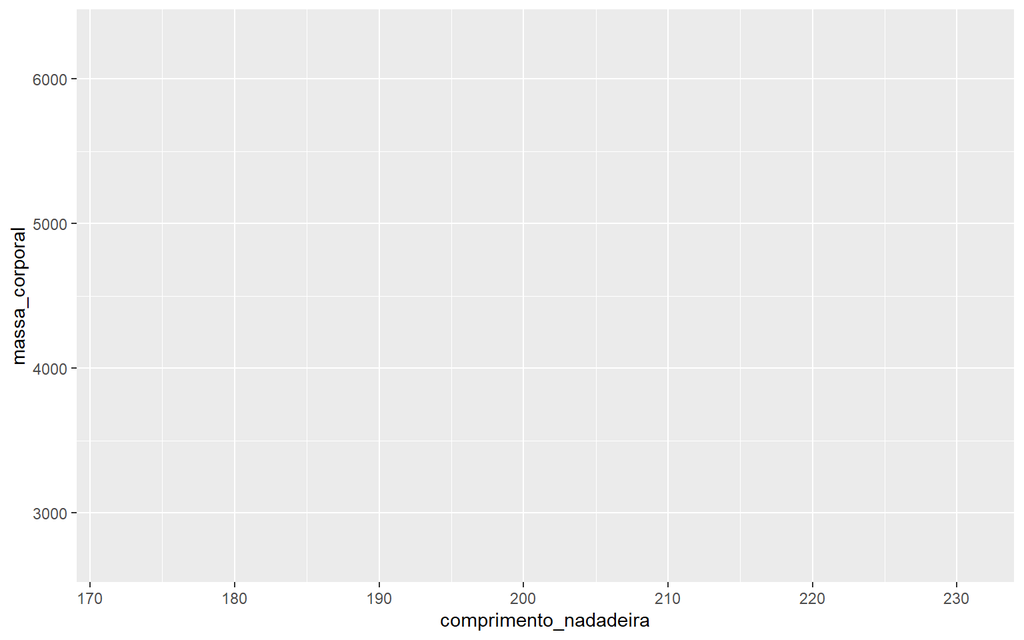

```r
ggplot(
  data = pinguins,
  aes(
    x = comprimento_nadadeira,
    y = massa_corporal
  )
)
```

Nesse exemplo:

- `ggplot()`: inicia a construção do gráfico.
- `data = pinguins`: informa qual conjunto de dados será utilizado.
- `aes()`: define as variáveis que serão representadas nos eixos.
- `x`: variável do eixo horizontal.
- `y`: variável do eixo vertical.

Observe que ainda não aparecem pontos, pois precisamos informar como os dados serão representados.

#### Segunda camada: adicionando os pontos

Vamos acrescentar `geom_point()`.

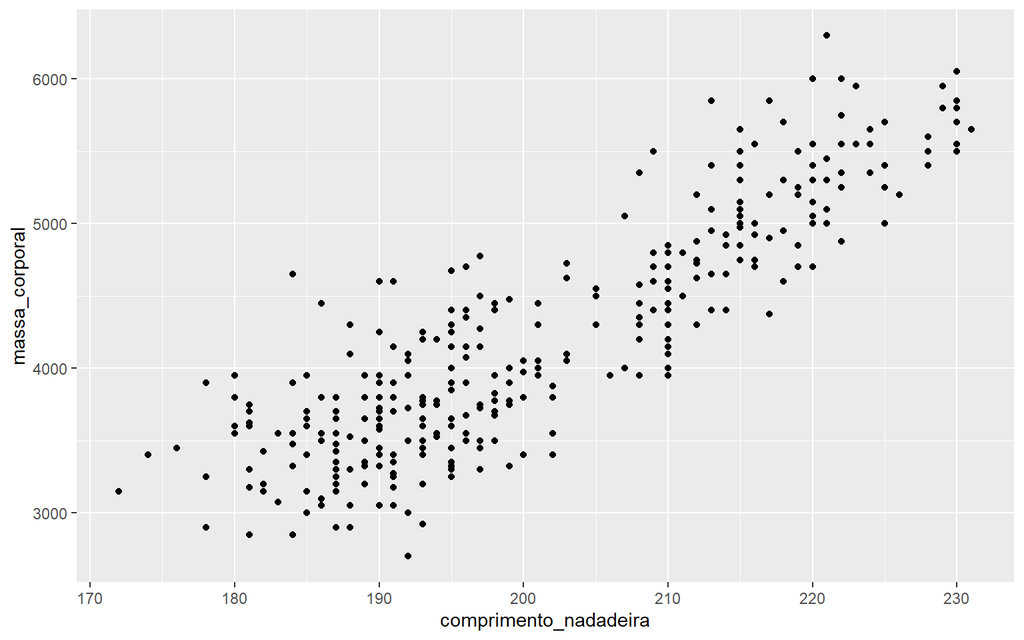

```r
ggplot(
  data = pinguins,
  aes(
    x = comprimento_nadadeira,
    y = massa_corporal
  )
) +
  geom_point()
```

Agora temos um gráfico de dispersão.

Observe que cada ponto representa um pinguim. A posição do ponto depende do comprimento da nadadeira e da massa corporal do indivíduo.

#### Terceira camada: nomeando os eixos e o gráfico

Podemos utilizar a função `labs()` para adicionar títulos.

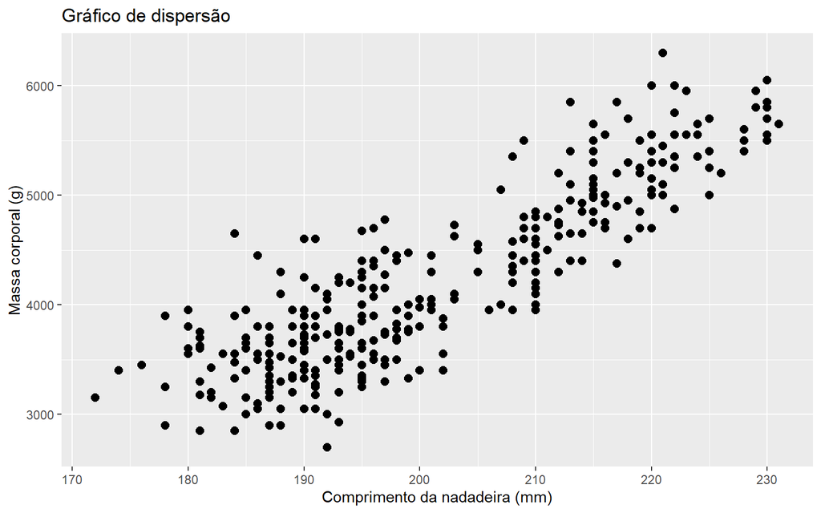

```r
ggplot(
  data = pinguins,
  aes(
    x = comprimento_nadadeira,
    y = massa_corporal
  )
) +
  geom_point(size = 2.5) +
  labs(
    x = "Comprimento da nadadeira (mm)",
    y = "Massa corporal (g)",
    title = "Gráfico de dispersão"
  )
```

Observe que utilizamos o sinal `+` para acrescentar uma nova camada.

#### Quarta camada: modificando o tema

O `ggplot2` possui diferentes temas que modificam a aparência do gráfico.

Vamos experimentar alguns deles.

**Tema padrão**

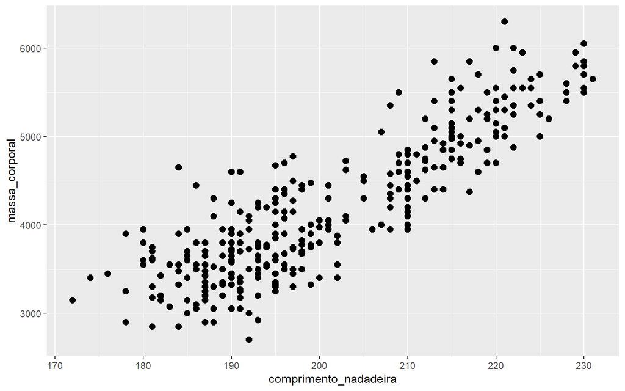

```r
ggplot(pinguins,
       aes(x = comprimento_nadadeira,
           y = massa_corporal)) +
  geom_point(size = 2.5)
```

**Tema claro: `theme_light()`**

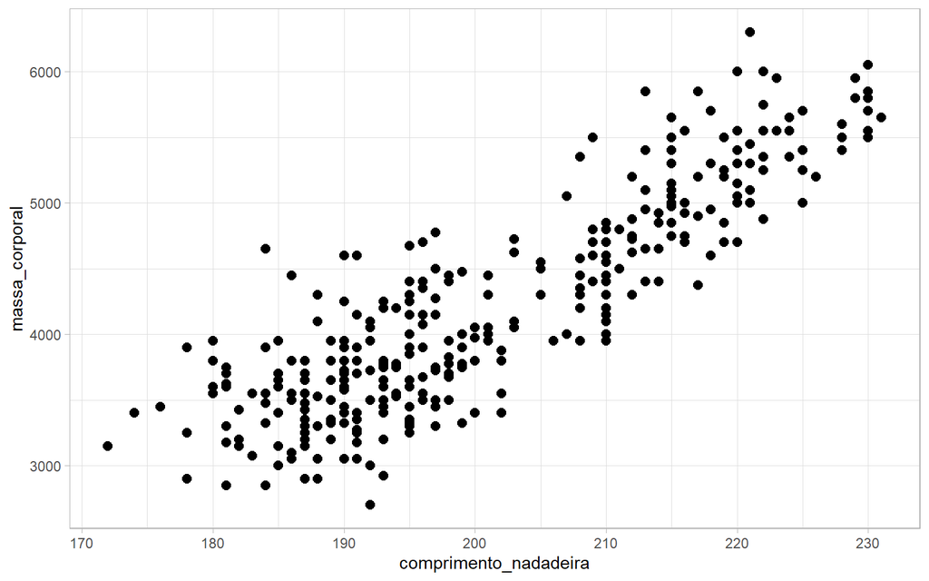

```r
ggplot(pinguins,
       aes(x = comprimento_nadadeira,
           y = massa_corporal)) +
  geom_point(size = 2.5) +
  theme_light()
```

**Tema minimalista: `theme_minimal()`**

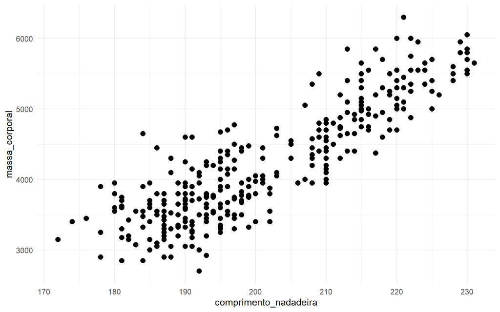

```r
ggplot(pinguins,
       aes(x = comprimento_nadadeira,
           y = massa_corporal)) +
  geom_point(size = 2.5) +
  theme_minimal()
```

**Tema escuro: `theme_dark()`**

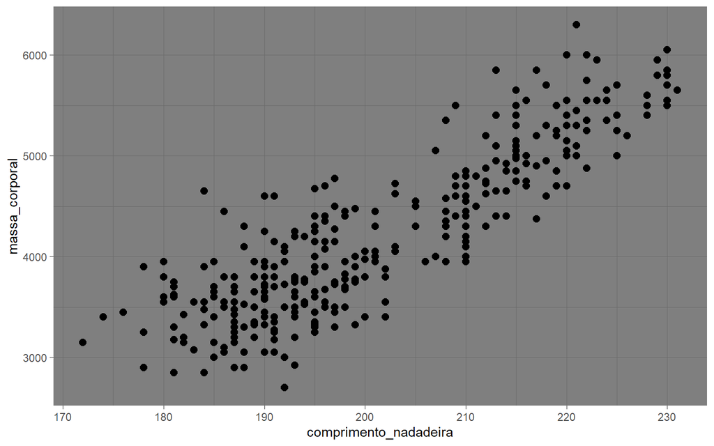

```r
ggplot(pinguins,
       aes(x = comprimento_nadadeira,
           y = massa_corporal)) +
  geom_point(size = 2.5) +
  theme_dark()
```

Qual desses temas vocês preferem?

#### Quinta camada: identificando os grupos por cores

Nosso conjunto de dados contém pinguins de diferentes ilhas.

Podemos utilizar cores para identificar cada uma delas.

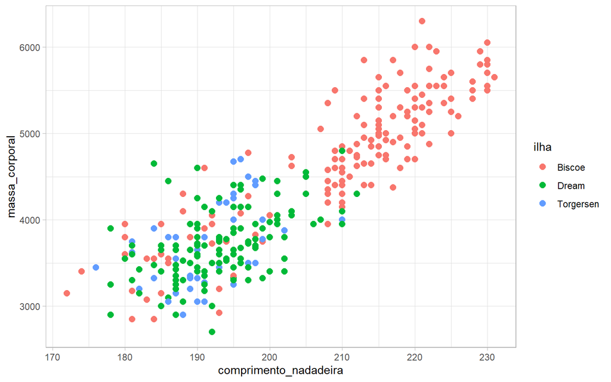

```r
ggplot(pinguins,
       aes(x = comprimento_nadadeira,
           y = massa_corporal,
           color = ilha)) +
  geom_point(size = 2.5) +
  theme_light()
```

Observe que adicionamos `color = ilha` dentro de `aes()`.

Assim, informamos ao R que a cor dos pontos deve variar conforme a ilha.

O `ggplot2` cria automaticamente uma legenda para identificar os grupos.

#### Sexta camada: personalizando o gráfico

Podemos utilizar a função `theme()` para modificar elementos específicos.

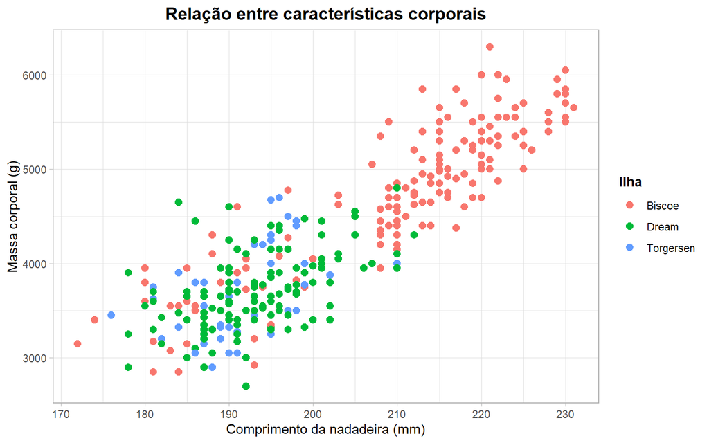

```r
ggplot(pinguins,
       aes(x = comprimento_nadadeira,
           y = massa_corporal,
           color = ilha)) +
  geom_point(size = 2.5) +
  labs(
    x = "Comprimento da nadadeira (mm)",
    y = "Massa corporal (g)",
    color = "Ilha",
    title = "Relação entre características corporais"
  ) +
  theme_light() +
  theme(
    legend.position = "right",
    legend.title = element_text(
      size = 11,
      face = "bold"
    ),
    plot.title = element_text(
      color = "black",
      size = 14,
      face = "bold",
      hjust = 0.5
    )
  )
```

Nesse exemplo:

- `legend.position`: define a posição da legenda.
- `legend.title`: altera a aparência do título da legenda.
- `plot.title`: altera a aparência do título do gráfico.
- `face = "bold"`: coloca o texto em negrito.
- `hjust = 0.5`: centraliza o título.

Podemos consultar outras opções de personalização utilizando:

```r
help("theme")
```

### 6.4. Adicionando uma linha de regressão

Também podemos acrescentar uma linha de regressão ao gráfico de dispersão.

Para isso, utilizamos `geom_smooth()`.

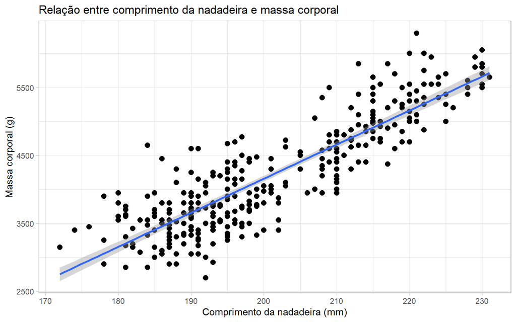

```r
ggplot(pinguins,
       aes(x = comprimento_nadadeira,
           y = massa_corporal)) +
  geom_point(size = 2.5) +
  geom_smooth(method = "lm") +
  labs(
    x = "Comprimento da nadadeira (mm)",
    y = "Massa corporal (g)",
    title = "Relação entre comprimento da nadadeira e massa corporal"
  ) +
  theme_light()
```

O argumento `method = "lm"` indica que queremos ajustar uma regressão linear.

A faixa sombreada ao redor da reta representa, por padrão, um intervalo de confiança de 95% para a média estimada.

Podemos retirar essa faixa utilizando `se = FALSE`.

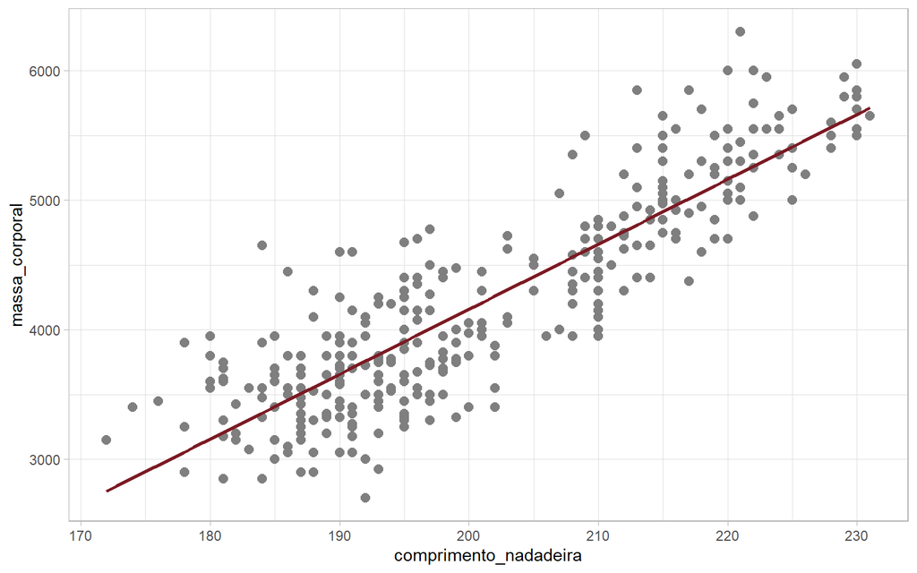

```r
ggplot(pinguins,
       aes(x = comprimento_nadadeira,
           y = massa_corporal)) +
  geom_point(size = 2.5, color = "gray50") +
  geom_smooth(
    method = "lm",
    se = FALSE,
    color = "#7C1A23"
  ) +
  theme_light()
```

Se quisermos identificar as diferentes ilhas, podemos manter as cores dos pontos e acrescentar uma única reta para o conjunto de observações.

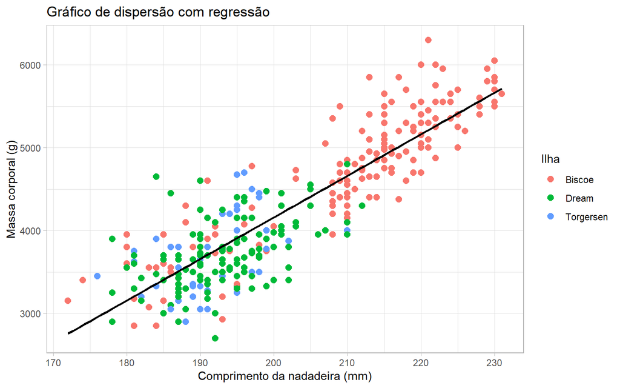

```r
ggplot(pinguins,
       aes(x = comprimento_nadadeira,
           y = massa_corporal)) +
  geom_point(aes(color = ilha), size = 2.5) +
  geom_smooth(
    method = "lm",
    se = FALSE,
    color = "black"
  ) +
  labs(
    x = "Comprimento da nadadeira (mm)",
    y = "Massa corporal (g)",
    color = "Ilha",
    title = "Gráfico de dispersão com regressão"
  ) +
  theme_light()
```

### 6.5. Adicionando legendas, subtítulos e fontes

Podemos acrescentar outras informações ao gráfico utilizando `labs()`.

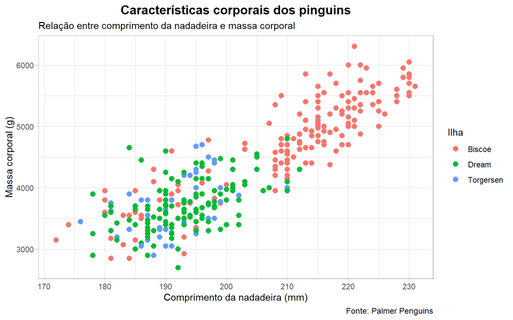

```r
ggplot(pinguins,
       aes(x = comprimento_nadadeira,
           y = massa_corporal,
           color = ilha)) +
  geom_point(size = 2.5) +
  labs(
    x = "Comprimento da nadadeira (mm)",
    y = "Massa corporal (g)",
    color = "Ilha",
    title = "Características corporais dos pinguins",
    subtitle = "Relação entre comprimento da nadadeira e massa corporal",
    caption = "Fonte: Palmer Penguins"
  ) +
  theme_light() +
  theme(
    plot.title = element_text(
      size = 14,
      face = "bold",
      hjust = 0.5
    ),
    plot.caption = element_text(
      size = 9,
      hjust = 1
    )
  )
```

Também podemos utilizar a função `ggtitle()` para adicionar títulos e subtítulos.

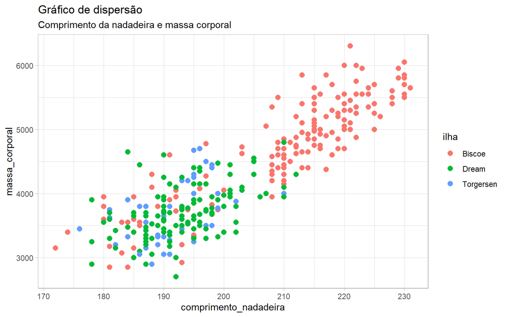

```r
ggplot(pinguins,
       aes(x = comprimento_nadadeira,
           y = massa_corporal,
           color = ilha)) +
  geom_point(size = 2.5) +
  theme_light() +
  ggtitle(
    "Gráfico de dispersão",
    subtitle = "Comprimento da nadadeira e massa corporal"
  )
```

### 6.6. Modificando os limites dos eixos

Em algumas situações, queremos observar apenas uma região específica do gráfico.

Podemos utilizar `coord_cartesian()` para aproximar a visualização.

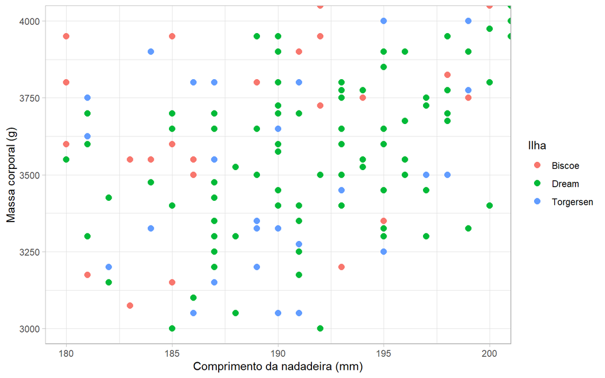

```r
ggplot(pinguins,
       aes(x = comprimento_nadadeira,
           y = massa_corporal,
           color = ilha)) +
  geom_point(size = 2.5) +
  labs(
    x = "Comprimento da nadadeira (mm)",
    y = "Massa corporal (g)",
    color = "Ilha"
  ) +
  theme_light() +
  coord_cartesian(
    xlim = c(180, 200),
    ylim = c(3000, 4000)
  )
```

Nesse exemplo, estamos visualizando apenas a região entre 180 e 200 mm no eixo horizontal e entre 3.000 e 4.000 g no eixo vertical.

Também existem as funções `xlim()` e `ylim()`, mas elas podem descartar observações fora dos limites especificados.

Por isso, quando queremos apenas aproximar uma região do gráfico, podemos utilizar `coord_cartesian()`.

### 6.7. Organizando dois gráficos lado a lado

Podemos salvar gráficos em objetos e apresentá-los lado a lado.

Para isso, vamos utilizar o pacote `gridExtra`.

```r
library(gridExtra)
```

Primeiro, vamos construir o gráfico completo.

```r
grafico <- ggplot(pinguins,
                  aes(x = comprimento_nadadeira,
                      y = massa_corporal,
                      color = ilha)) +
  geom_point(size = 2.5) +
  labs(
    x = "Comprimento da nadadeira (mm)",
    y = "Massa corporal (g)",
    color = "Ilha",
    title = "Gráfico completo"
  ) +
  theme_light()
```

Agora, vamos construir outro gráfico, mostrando apenas uma região dos dados.

```r
grafico_zoom <- ggplot(pinguins,
                       aes(x = comprimento_nadadeira,
                           y = massa_corporal,
                           color = ilha)) +
  geom_point(size = 2.5) +
  coord_cartesian(
    xlim = c(180, 200),
    ylim = c(3000, 4000)
  ) +
  labs(
    x = "Comprimento da nadadeira (mm)",
    y = "Massa corporal (g)",
    color = "Ilha",
    title = "Região ampliada"
  ) +
  theme_light()
```

Vamos apresentar os gráficos lado a lado.

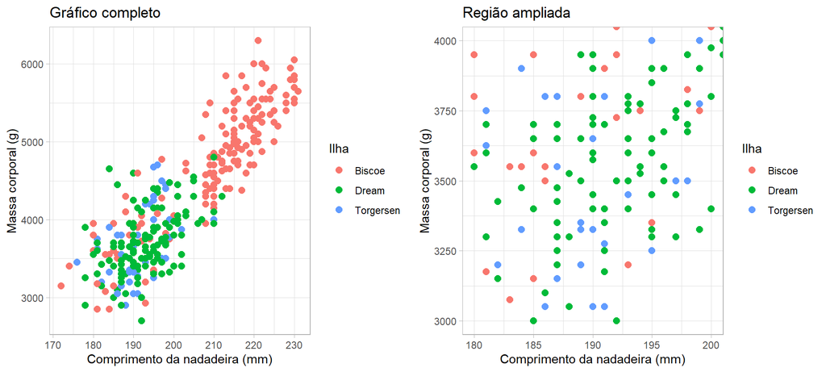

```r
grid.arrange(grafico, grafico_zoom, ncol = 2)
```

O argumento `ncol = 2` indica que queremos organizar os gráficos em duas colunas.

Experimente substituir por `ncol = 1`. O que acontece?

### 6.8. Representando médias com stat_summary()

Também podemos utilizar o `ggplot2` para representar medidas estatísticas.

Imagine que queremos comparar a massa corporal média dos pinguins entre as diferentes ilhas.

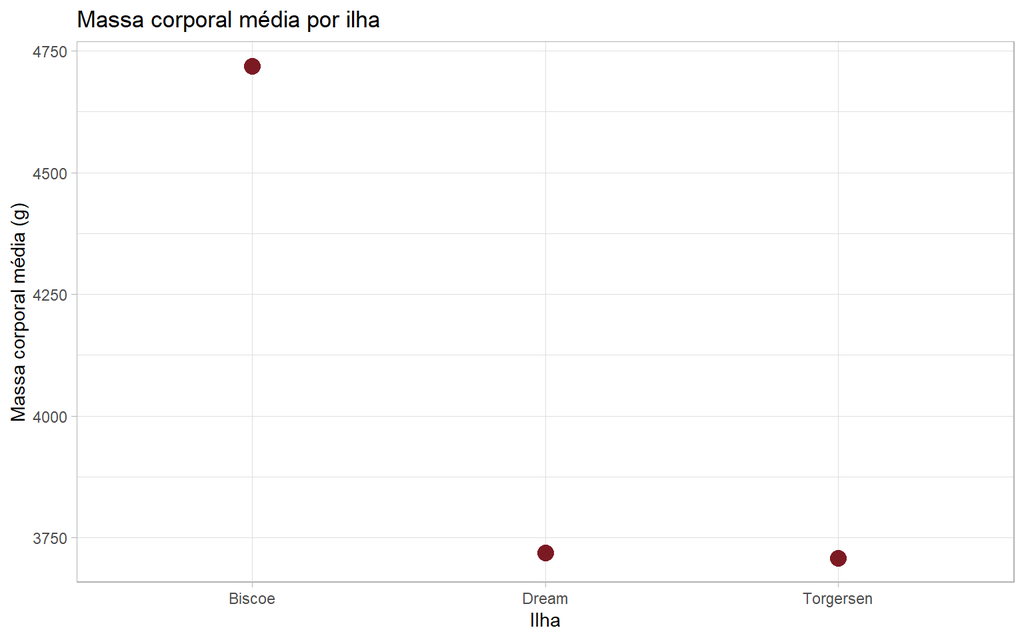

```r
ggplot(pinguins,
       aes(x = ilha,
           y = massa_corporal)) +
  stat_summary(
    fun = mean,
    geom = "point",
    size = 4,
    color = "#7C1A23"
  ) +
  labs(
    x = "Ilha",
    y = "Massa corporal média (g)",
    title = "Massa corporal média por ilha"
  ) +
  theme_light()
```

Nesse exemplo:

- `fun = mean`: informa que queremos calcular a média.
- `geom = "point"`: representa cada média por um ponto.
- `size = 4`: define o tamanho dos pontos.

Também podemos conectar as médias por uma linha.

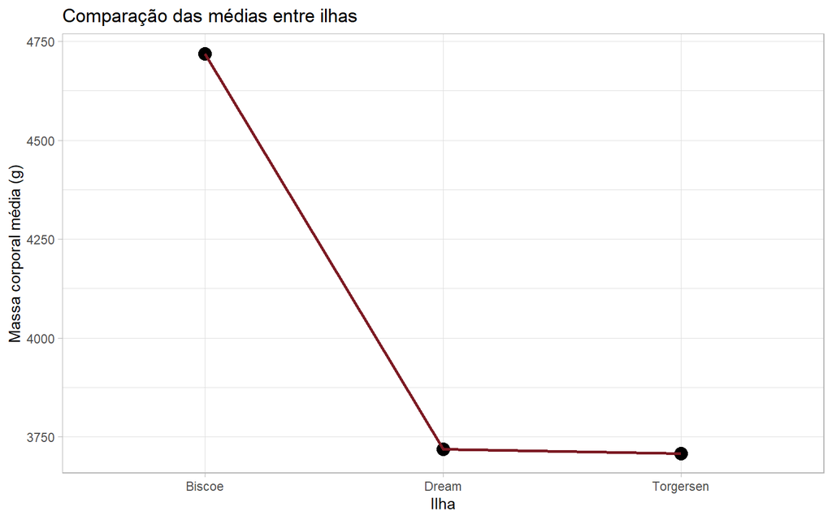

```r
ggplot(pinguins,
       aes(x = ilha,
           y = massa_corporal,
           group = 1)) +
  stat_summary(
    fun = mean,
    geom = "point",
    size = 4,
    color = "black"
  ) +
  stat_summary(
    fun = mean,
    geom = "line",
    color = "#7C1A23",
    linewidth = 1
  ) +
  labs(
    x = "Ilha",
    y = "Massa corporal média (g)",
    title = "Comparação das médias entre ilhas"
  ) +
  theme_light()
```

Nesse caso, `group = 1` permite conectar os pontos por uma única linha. Como as ilhas são categorias, a linha serve apenas como recurso visual, não representando uma sequência temporal ou contínua.

### 6.9. Gráficos de barras

Os gráficos de barras são úteis para representar contagens ou comparar valores entre categorias.

Vamos começar verificando quantos pinguins existem em cada ilha.

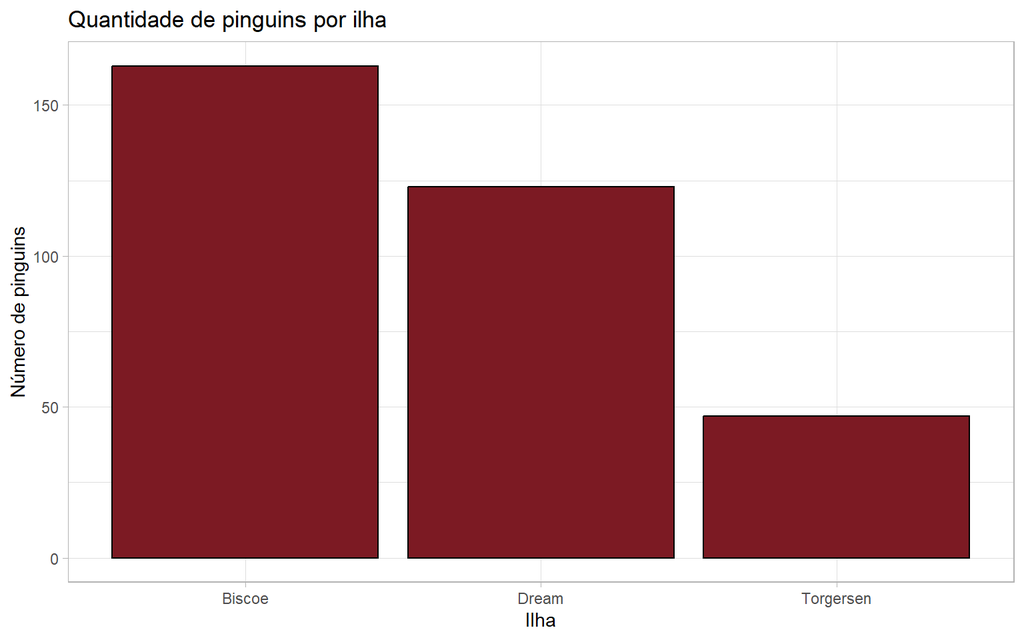

```r
ggplot(pinguins,
       aes(x = ilha)) +
  geom_bar(
    color = "black",
    fill = "#7C1A23"
  ) +
  labs(
    x = "Ilha",
    y = "Número de pinguins",
    title = "Quantidade de pinguins por ilha"
  ) +
  theme_light()
```

A função `geom_bar()` conta automaticamente o número de observações em cada categoria.

#### Gráfico de barras agrupadas

Também podemos dividir as barras de acordo com o ano de observação.

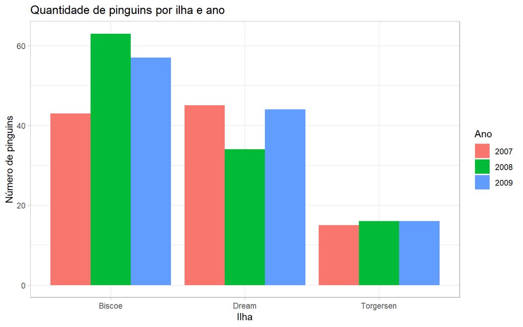

```r
ggplot(pinguins,
       aes(x = ilha,
           fill = factor(ano))) +
  geom_bar(position = "dodge") +
  labs(
    x = "Ilha",
    y = "Número de pinguins",
    fill = "Ano",
    title = "Quantidade de pinguins por ilha e ano"
  ) +
  theme_light()
```

O argumento `position = "dodge"` posiciona as barras lado a lado.

Observe também que utilizamos `factor(ano)` para tratar os anos como categorias.

### 6.10. Histogramas

O histograma permite visualizar a distribuição de uma variável quantitativa.

Vamos investigar a distribuição da massa corporal dos pinguins.

#### Histograma de frequências

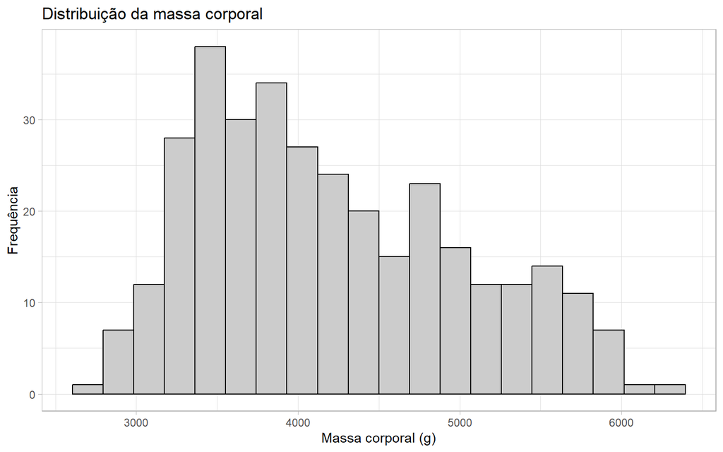

```r
ggplot(pinguins,
       aes(x = massa_corporal)) +
  geom_histogram(
    bins = 20,
    color = "black",
    fill = "gray80"
  ) +
  labs(
    x = "Massa corporal (g)",
    y = "Frequência",
    title = "Distribuição da massa corporal"
  ) +
  theme_light()
```

O argumento `bins = 20` define a quantidade de intervalos do histograma.

Experimente modificar esse valor para 10 ou 30 e observe como a aparência do gráfico muda.

#### Histograma por densidade

Também podemos representar a densidade em vez da frequência absoluta.

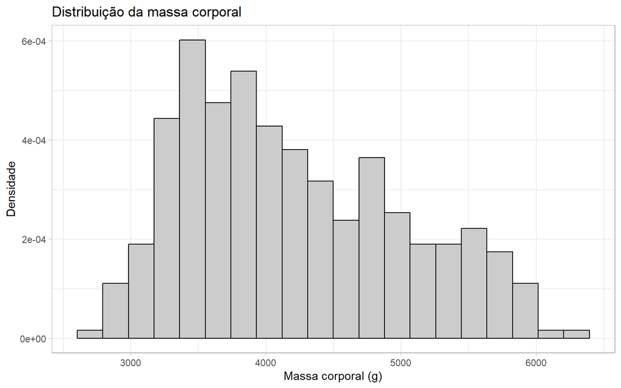

```r
ggplot(pinguins,
       aes(x = massa_corporal)) +
  geom_histogram(
    aes(y = after_stat(density)),
    bins = 20,
    color = "black",
    fill = "gray80"
  ) +
  labs(
    x = "Massa corporal (g)",
    y = "Densidade",
    title = "Distribuição da massa corporal"
  ) +
  theme_light()
```

#### Adicionando uma curva de densidade

Podemos acrescentar uma curva suavizada à distribuição dos dados.

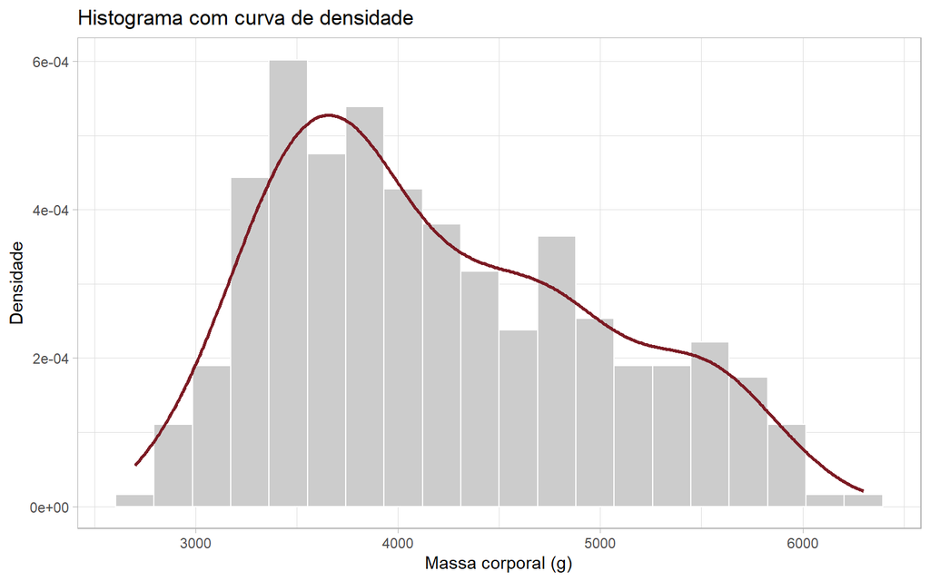

```r
ggplot(pinguins,
       aes(x = massa_corporal)) +
  geom_histogram(
    aes(y = after_stat(density)),
    bins = 20,
    color = "white",
    fill = "gray80"
  ) +
  geom_density(
    color = "#7C1A23",
    linewidth = 1
  ) +
  labs(
    x = "Massa corporal (g)",
    y = "Densidade",
    title = "Histograma com curva de densidade"
  ) +
  theme_light()
```

Observe que adicionamos a curva com `geom_density()` utilizando o sinal `+`.

### 6.11. Boxplot

O boxplot, também chamado de diagrama de caixa, permite comparar a distribuição de uma variável quantitativa entre diferentes grupos.

Vamos comparar a massa corporal dos pinguins entre as ilhas.

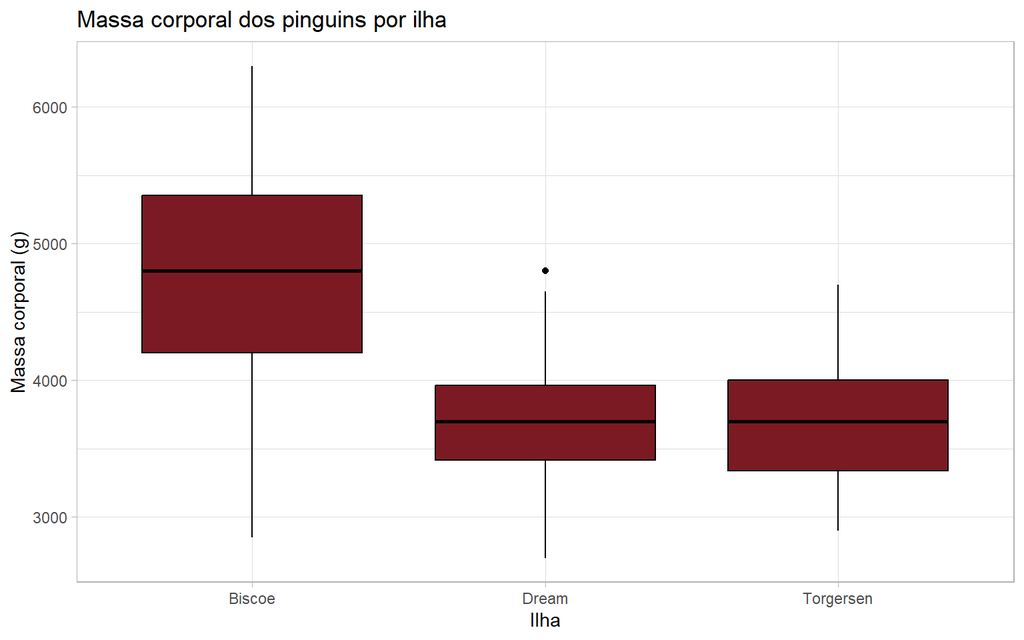

```r
ggplot(pinguins,
       aes(x = ilha,
           y = massa_corporal)) +
  geom_boxplot(
    fill = "#7C1A23",
    color = "black"
  ) +
  labs(
    x = "Ilha",
    y = "Massa corporal (g)",
    title = "Massa corporal dos pinguins por ilha"
  ) +
  theme_light()
```

Podemos também utilizar cores diferentes para identificar cada ilha.

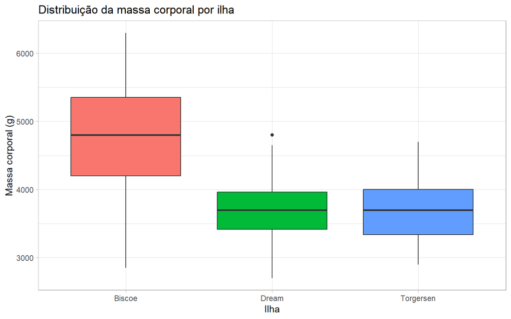

```r
ggplot(pinguins,
       aes(x = ilha,
           y = massa_corporal,
           fill = ilha)) +
  geom_boxplot() +
  labs(
    x = "Ilha",
    y = "Massa corporal (g)",
    title = "Distribuição da massa corporal por ilha"
  ) +
  theme_light() +
  theme(legend.position = "none")
```

A legenda foi retirada porque os nomes das ilhas já aparecem no eixo horizontal.

#### Acrescentando as observações individuais

Podemos combinar o boxplot com os valores individuais utilizando `geom_jitter()`.

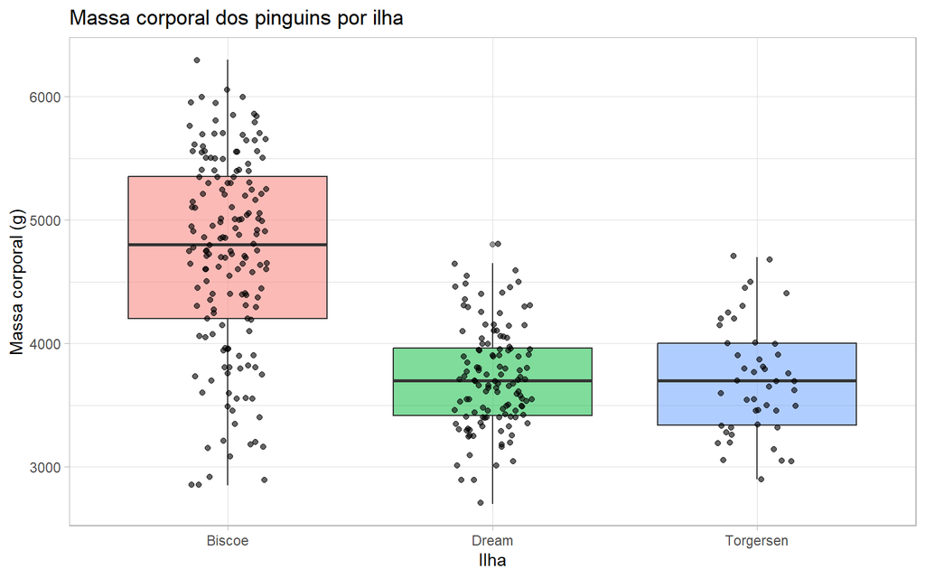

```r
ggplot(pinguins,
       aes(x = ilha,
           y = massa_corporal,
           fill = ilha)) +
  geom_boxplot(alpha = 0.5) +
  geom_jitter(
    width = 0.15,
    size = 1.5,
    alpha = 0.6
  ) +
  labs(
    x = "Ilha",
    y = "Massa corporal (g)",
    title = "Massa corporal dos pinguins por ilha"
  ) +
  theme_light() +
  theme(legend.position = "none")
```

A função `geom_jitter()` adiciona pequenos deslocamentos horizontais aos pontos para reduzir a sobreposição entre observações.

### 6.12. Outras funções estatísticas

Além dos gráficos, podemos utilizar algumas funções para explorar as características dos pinguins.

Vamos trabalhar com o comprimento da nadadeira e a massa corporal.

**Média**

```r
mean(pinguins$comprimento_nadadeira)
```

```
## [1] 200.967
```

**Variância**

```r
var(pinguins$comprimento_nadadeira)
```

```
## [1] 196.4417
```

**Desvio padrão**

```r
sd(pinguins$comprimento_nadadeira)
```

```
## [1] 14.01577
```

**Covariância entre duas variáveis**

```r
cov(
  pinguins$comprimento_nadadeira,
  pinguins$massa_corporal
)
```

```
## [1] 9852.192
```

**Coeficiente de correlação**

```r
cor(
  pinguins$comprimento_nadadeira,
  pinguins$massa_corporal
)
```

```
## [1] 0.8729789
```

**Coeficiente de variação (%)**

```r
(
  sd(pinguins$comprimento_nadadeira) /
  mean(pinguins$comprimento_nadadeira)
) * 100
```

```
## [1] 6.974164
```

**Quantis**

```r
quantile(pinguins$comprimento_nadadeira)
```

```
##   0%  25%  50%  75% 100%
##  172  190  197  213  231
```

### 6.13. Salvando nossos gráficos

Depois de construir um gráfico, podemos salvá-lo para utilizar em relatórios, apresentações ou outros documentos.

Vamos criar um gráfico e armazená-lo em um objeto.

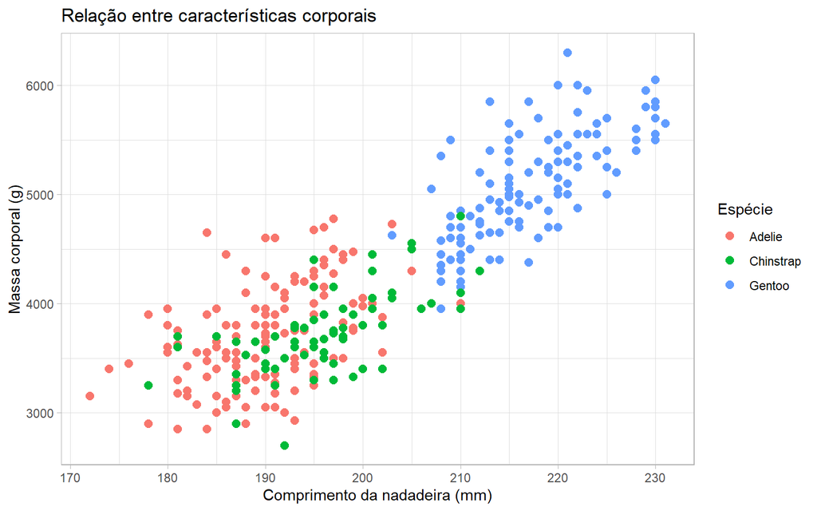

```r
grafico_final <- ggplot(pinguins,
                        aes(x = comprimento_nadadeira,
                            y = massa_corporal,
                            color = especie)) +
  geom_point(size = 2.5) +
  labs(
    x = "Comprimento da nadadeira (mm)",
    y = "Massa corporal (g)",
    color = "Espécie",
    title = "Relação entre características corporais"
  ) +
  theme_light()

grafico_final
```

Podemos utilizar a função `ggsave()` para salvar o gráfico em diferentes formatos.

```r
ggsave(
  filename = "grafico_pinguins.png",
  plot = grafico_final,
  width = 8,
  height = 5,
  dpi = 300
)
```

Também podemos salvar o gráfico em PDF.

```r
ggsave(
  filename = "grafico_pinguins.pdf",
  plot = grafico_final,
  width = 8,
  height = 5
)
```

Esses arquivos serão salvos na pasta de trabalho utilizada pelo R.

### 6.14. Vamos praticar!

Agora que conhecemos diferentes possibilidades de visualização, vamos utilizar o conjunto `pinguins` para resolver alguns desafios.

1. Construa um gráfico de dispersão relacionando o comprimento do bico com a massa corporal.
2. Identifique as espécies utilizando cores diferentes.
3. Acrescente uma linha de regressão ao gráfico.
4. Modifique o título, os nomes dos eixos e o tema.
5. Construa um histograma para visualizar a distribuição do comprimento das nadadeiras.
6. Compare a massa corporal dos pinguins entre as espécies utilizando um boxplot.
7. Construa um gráfico de barras mostrando o número de pinguins por ilha.
8. Escolha dois gráficos, salve-os em objetos e apresente-os lado a lado.
9. Salve um dos gráficos em formato PNG.

## 7. Família apply

Entretanto, o R possui funções que permitem aplicar operações diretamente a diferentes partes de um objeto, sem precisar escrever explicitamente uma estrutura de repetição.

Essas funções pertencem à chamada **família `apply`**.

Vamos conhecer algumas delas:

- `apply()`: aplica uma função às linhas ou colunas de uma matriz.
- `lapply()`: aplica uma função aos elementos de uma lista e retorna outra lista.
- `sapply()`: funciona de forma semelhante ao `lapply()`, mas tenta simplificar o resultado.
- `tapply()`: aplica uma função aos valores separados por grupos.
- `mapply()`: aplica uma função a elementos correspondentes de dois ou mais objetos.

### 7.1. Conhecendo a função apply()

Vamos começar com uma matriz contendo a altura de quatro plantas avaliadas em três momentos.

```r
alturas <- matrix(
  c(12, 14, 13, 15,
    16, 18, 17, 19,
    20, 22, 21, 24),
  nrow = 4,
  ncol = 3
)

rownames(alturas) <- c("Planta_1", "Planta_2",
                       "Planta_3", "Planta_4")

colnames(alturas) <- c("Avaliacao_1", "Avaliacao_2",
                       "Avaliacao_3")

alturas
```

```
##          Avaliacao_1 Avaliacao_2 Avaliacao_3
## Planta_1          12          16          20
## Planta_2          14          18          22
## Planta_3          13          17          21
## Planta_4          15          19          24
```

Imagine que queremos calcular a altura média das plantas em cada avaliação.

Poderíamos utilizar a função `mean()` para cada coluna:

```r
mean(alturas[, 1])
```

```
## [1] 13.5
```

```r
mean(alturas[, 2])
```

```
## [1] 17.5
```

```r
mean(alturas[, 3])
```

```
## [1] 21.75
```

Mas existe uma maneira mais simples de realizar essas operações.

Podemos utilizar a função `apply()`.

Sua estrutura básica é:

```r
apply(X, MARGIN, FUN)
```

Nesse caso:

- `X`: objeto que contém os dados.
- `MARGIN`: indica se a operação será realizada nas linhas ou colunas.
- `FUN`: função que será aplicada.

**Calculando a média das colunas**

```r
apply(alturas, 2, mean)
```

```
## Avaliacao_1 Avaliacao_2 Avaliacao_3
##       13.50       17.50       21.75
```

O número `2` indica que queremos aplicar a função às colunas.

Portanto, o R calcula a média das alturas em cada avaliação.

**Calculando a média das linhas**

Agora, queremos saber a altura média de cada planta considerando as três avaliações.

```r
apply(alturas, 1, mean)
```

```
## Planta_1 Planta_2 Planta_3 Planta_4
## 16.00000 18.00000 17.00000 19.33333
```

O número `1` indica que queremos aplicar a função às linhas.

Assim, cada resultado corresponde à média de uma planta.

**Vamos experimentar outras funções!**

```r
apply(alturas, 2, max)
```

```
## Avaliacao_1 Avaliacao_2 Avaliacao_3
##          15          19          24
```

```r
apply(alturas, 2, min)
```

```
## Avaliacao_1 Avaliacao_2 Avaliacao_3
##          12          16          20
```

```r
apply(alturas, 1, sum)
```

```
## Planta_1 Planta_2 Planta_3 Planta_4
##       48       54       51       58
```

```r
apply(alturas, 2, sd)
```

```
## Avaliacao_1 Avaliacao_2 Avaliacao_3
##    1.290994    1.290994    1.707825
```

Observe que podemos utilizar diferentes funções dentro de `apply()`.

### 7.2. Conhecendo a função lapply()

A função `lapply()` permite aplicar uma mesma função aos elementos de uma lista.

Vamos criar uma lista com as alturas de três grupos de plantas.

```r
alturas_grupos <- list(
  Grupo_A = c(12, 14, 15, 13),
  Grupo_B = c(18, 20, 19, 21),
  Grupo_C = c(10, 11, 13, 12)
)

alturas_grupos
```

```
## $Grupo_A
## [1] 12 14 15 13
##
## $Grupo_B
## [1] 18 20 19 21
##
## $Grupo_C
## [1] 10 11 13 12
```

Queremos calcular a altura média de cada grupo.

Podemos fazer isso individualmente:

```r
mean(alturas_grupos$Grupo_A)
```

```
## [1] 13.5
```

```r
mean(alturas_grupos$Grupo_B)
```

```
## [1] 19.5
```

```r
mean(alturas_grupos$Grupo_C)
```

```
## [1] 11.5
```

Entretanto, podemos utilizar `lapply()` para realizar os três cálculos de uma só vez.

```r
lapply(alturas_grupos, mean)
```

```
## $Grupo_A
## [1] 13.5
##
## $Grupo_B
## [1] 19.5
##
## $Grupo_C
## [1] 11.5
```

A função percorre cada elemento da lista e calcula sua média.

**Observe:** o resultado também é uma lista.

Podemos utilizar outras funções.

```r
lapply(alturas_grupos, max)
```

```
## $Grupo_A
## [1] 15
##
## $Grupo_B
## [1] 21
##
## $Grupo_C
## [1] 13
```

```r
lapply(alturas_grupos, min)
```

```
## $Grupo_A
## [1] 12
##
## $Grupo_B
## [1] 18
##
## $Grupo_C
## [1] 10
```

```r
lapply(alturas_grupos, sd)
```

```
## $Grupo_A
## [1] 1.290994
##
## $Grupo_B
## [1] 1.290994
##
## $Grupo_C
## [1] 1.290994
```

```r
lapply(alturas_grupos, length)
```

```
## $Grupo_A
## [1] 4
##
## $Grupo_B
## [1] 4
##
## $Grupo_C
## [1] 4
```

### 7.3. Conhecendo a função sapply()

A função `sapply()` é semelhante à `lapply()`, mas tenta apresentar o resultado de uma forma mais simples.

Vamos utilizar a mesma lista de alturas.

```r
sapply(alturas_grupos, mean)
```

```
## Grupo_A Grupo_B Grupo_C
##    13.5    19.5    11.5
```

Compare com:

```r
lapply(alturas_grupos, mean)
```

```
## $Grupo_A
## [1] 13.5
##
## $Grupo_B
## [1] 19.5
##
## $Grupo_C
## [1] 11.5
```

```r
sapply(alturas_grupos, mean)
```

```
## Grupo_A Grupo_B Grupo_C
##    13.5    19.5    11.5
```

As duas funções calcularam as mesmas médias.

A diferença está na estrutura do resultado.

Enquanto `lapply()` retorna uma lista, `sapply()` tenta simplificar o resultado. Nesse exemplo, retorna um vetor numérico.

Podemos verificar:

```r
class(lapply(alturas_grupos, mean))
```

```
## [1] "list"
```

```r
class(sapply(alturas_grupos, mean))
```

```
## [1] "numeric"
```

**Aplicando sapply() aos dados dos pinguins**

Vamos retornar ao conjunto de dados utilizado na aula anterior.

Queremos calcular a média das principais características corporais dos pinguins.

Primeiro, vamos selecionar apenas as variáveis numéricas de interesse.

```r
medidas <- pinguins[, c(
  "comprimento_bico",
  "profundidade_bico",
  "comprimento_nadadeira",
  "massa_corporal"
)]

head(medidas)
```

```
##   comprimento_bico profundidade_bico comprimento_nadadeira massa_corporal
## 1             39.1              18.7                   181           3750
## 2             39.5              17.4                   186           3800
## 3             40.3              18.0                   195           3250
## 5             36.7              19.3                   193           3450
## 6             39.3              20.6                   190           3650
## 7             38.9              17.8                   181           3625
```

Agora, podemos calcular a média de cada variável.

```r
sapply(medidas, mean)
```

```
##      comprimento_bico     profundidade_bico comprimento_nadadeira
##              43.99279              17.16486             200.96697
##        massa_corporal
##            4207.05706
```

Também podemos calcular o desvio padrão:

```r
sapply(medidas, sd)
```

```
##      comprimento_bico     profundidade_bico comprimento_nadadeira
##              5.468668              1.969235             14.015765
##        massa_corporal
##            805.215802
```

Observe que o R realiza o cálculo para cada coluna selecionada.

### 7.4. Conhecendo a função tapply()

Até agora, calculamos médias de diferentes variáveis. Mas e se quisermos comparar a média de uma mesma variável entre diferentes grupos?

Por exemplo, queremos descobrir a massa corporal média dos pinguins em cada ilha.

Para isso, podemos utilizar `tapply()`.

Sua estrutura básica é:

```r
tapply(X, INDEX, FUN)
```

Em que:

- `X`: vetor com os valores que queremos analisar.
- `INDEX`: variável que identifica os grupos.
- `FUN`: função que será aplicada a cada grupo.

Vamos utilizar nosso conjunto de dados.

```r
tapply(
  pinguins$massa_corporal,
  pinguins$ilha,
  mean
)
```

```
##    Biscoe     Dream Torgersen
##  4719.172  3718.902  3708.511
```

Nesse exemplo, o R separa os valores de massa corporal por ilha e calcula a média de cada grupo.

Também podemos comparar as médias entre as espécies.

```r
tapply(
  pinguins$massa_corporal,
  pinguins$especie,
  mean
)
```

```
##    Adelie Chinstrap    Gentoo
##  3706.164  3733.088  5092.437
```

**Vamos experimentar outras funções!**

Qual é a maior massa corporal registrada em cada espécie?

```r
tapply(
  pinguins$massa_corporal,
  pinguins$especie,
  max
)
```

```
##    Adelie Chinstrap    Gentoo
##      4775      4800      6300
```

E o desvio padrão da massa corporal?

```r
tapply(
  pinguins$massa_corporal,
  pinguins$especie,
  sd
)
```

```
##    Adelie Chinstrap    Gentoo
##  458.6201  384.3351  501.4762
```

Observe que estamos aplicando a mesma função a diferentes grupos de observações.

### 7.5. Conhecendo a função mapply()

A função `mapply()` permite aplicar uma função a elementos correspondentes de dois ou mais objetos.

Vamos imaginar que temos dois vetores: um com a quantidade de mudas e outro com o preço de cada muda.

```r
quantidade <- c(10, 20, 15)

preco <- c(5, 4, 6)
```

Queremos calcular o custo total de cada compra.

Podemos multiplicar diretamente os vetores:

```r
quantidade * preco
```

```
## [1] 50 80 90
```

Também podemos utilizar `mapply()` para aplicar a função de multiplicação aos elementos correspondentes.

```r
mapply(
  FUN = function(x, y) x * y,
  quantidade,
  preco
)
```

```
## [1] 50 80 90
```

Nesse exemplo, criamos uma função que recebe dois valores, `x` e `y`, e retorna sua multiplicação.

O R aplica essa função aos elementos correspondentes dos dois vetores.

Observe que os resultados são iguais aos obtidos com a multiplicação direta. Nesse caso, `mapply()` é apenas uma alternativa para demonstrar seu funcionamento, pois a multiplicação vetorizada é mais simples.

### 7.6. Comparando as funções da família apply

Vamos retomar as principais diferenças entre as funções que aprendemos.

| Função | Quando utilizar |
| --- | --- |
| `apply()` | Para realizar operações nas linhas ou colunas de matrizes. |
| `lapply()` | Para aplicar uma função aos elementos de uma lista, mantendo o resultado como lista. |
| `sapply()` | Para aplicar uma função aos elementos de uma lista ou data frame, tentando simplificar o resultado. |
| `tapply()` | Para aplicar uma função aos valores separados por grupos. |
| `mapply()` | Para aplicar uma função a elementos correspondentes de vários objetos. |